# Audit: MapBiomas deforestation and secondary vegetation

Published

October 6, 2026

Source: MapBiomas, Deforestation and Secondary Vegetation statistics by municipality, Collection 9 (August 2024), file dated 2025-04-24. Raw file: `_data/raw/mapbiomas/mapbiomas_munic.xlsx`, sheet `DEF_SECVEG`. Pipeline script: `_scripts/01-env-deforestation.R`. Interim output: `_data/interim/mapbiomas_deforestation_amz_1987_2023.rds`.

```r
mapbiomas_raw <- read_xlsx("_data/raw/mapbiomas/mapbiomas_munic.xlsx", sheet = "DEF_SECVEG")
biome <- read_delim("_data/raw/ibge/ibge_bioma.csv", delim = ";",
                    col_types = cols(.default = col_character()),
                    locale = locale(encoding = "UTF-8"), show_col_types = FALSE) %>%
  filter(str_detect(Geocódigo, "^[0-9]{7}$"))
biome_amz <- biome %>% filter(`Bioma predominante` == "Amazônia")
defor <- read_rds("_data/interim/mapbiomas_deforestation_amz_1987_2023.rds")

AMZ_STATES <- c("Acre", "Amapá", "Amazonas", "Maranhão", "Mato Grosso",
                "Pará", "Rondônia", "Roraima", "Tocantins")
FOREST_TR <- c("Veg. Primária", "Veg. Secundária")
DEFOR_TR  <- c("Supressão Veg. Primária", "Supressão Veg. Secundária")
year_cols <- as.character(1985:2023)
```

## Q1. Is the raw sheet complete and keyed as expected?

What is checked: dimensions, distinct geocodes and their length, missing values in the year columns, the transition classes present, and the size of the nine-state subset the pipeline starts from.

```r
tibble(
  rows = nrow(mapbiomas_raw),
  cols = ncol(mapbiomas_raw),
  geocodes = n_distinct(mapbiomas_raw$geocode),
  geocode_lengths = paste(unique(nchar(as.character(mapbiomas_raw$geocode))), collapse = ","),
  na_in_year_cols = sum(is.na(mapbiomas_raw[, year_cols]))
)
```

```
# A tibble: 1 × 5
    rows  cols geocodes geocode_lengths na_in_year_cols
   <int> <int>    <int> <chr>                     <int>
1 264692    51     5571 7                             0
```

```r
mapbiomas_raw %>% count(transition_name)
```

```
# A tibble: 8 × 2
  transition_name                      n
  <chr>                            <int>
1 Antrópico                        64633
2 Ignorado                          8421
3 Outras transições                59679
4 Recuperação para Veg. Secundária 28345
5 Supressão Veg. Primária          16543
6 Supressão Veg. Secundária        16278
7 Veg. Primária                    28330
8 Veg. Secundária                  42463
```

```r
nine <- mapbiomas_raw %>% filter(state %in% AMZ_STATES)
tibble(rows_nine_states = nrow(nine),
       geocodes_nine_states = n_distinct(nine$geocode),
       biome_munis_present = sum(biome_amz$Geocódigo %in% as.character(nine$geocode)))
```

```
# A tibble: 1 × 3
  rows_nine_states geocodes_nine_states biome_munis_present
             <int>                <int>               <int>
1            45801                  808                 503
```

**Finding.** 264,692 rows and 51 columns; 5,571 geocodes, all seven digits; no missing value in the 39 year columns; eight transition classes. The nine Amazon states hold 45,801 rows and 808 municipalities, and all 503 municipalities of the IBGE biome list are among them. **Decision.** none required. **Assertion.** `01-env-deforestation.R`, raw-state block (`N_MUNIC_BR_EXPECTED`, `N_MUNIC_STATES_EXPECTED`).

## Q2. Are 1985 and 1986 zero for vegetation suppression?

What is checked: for the two suppression classes, the number of municipalities with a nonzero value in each of the first four years and in the last year of the series, nationally.

```r
mapbiomas_raw %>%
  filter(transition_name %in% DEFOR_TR) %>%
  select(transition_name, `1985`, `1986`, `1987`, `1988`, `2023`) %>%
  pivot_longer(-transition_name, names_to = "year", values_to = "area") %>%
  group_by(transition_name, year) %>%
  summarise(rows_nonzero = sum(area != 0), total_ha = sum(area), .groups = "drop") %>%
  pivot_wider(names_from = year, values_from = c(rows_nonzero, total_ha))
```

```
# A tibble: 2 × 11
  transition_name           rows_nonzero_1985 rows_nonzero_1986 rows_nonzero_1987 rows_nonzero_1988
  <chr>                                 <int>             <int>             <int>             <int>
1 Supressão Veg. Primária                   0                 0             14287             14255
2 Supressão Veg. Secundária                 0                 0                 0                 0
# ℹ 6 more variables: rows_nonzero_2023 <int>, total_ha_1985 <dbl>, total_ha_1986 <dbl>,
#   total_ha_1987 <dbl>, total_ha_1988 <dbl>, total_ha_2023 <dbl>
```

**Finding.** Both suppression classes are zero in every municipality in 1985 and 1986, the first two years of the Landsat series. 1987 is the first year with observed primary suppression; secondary suppression starts in 1989. 2023 carries values. **Decision.** D-2026-10-06-a: `MAPBIOMAS_YEARS = 1987:2023`. **Assertion.** `01-env-deforestation.R`, raw-state block (`suppression_dropped_years`).

## Q3. Which level-1 classes compose the four transitions the pipeline sums?

What is checked: the land-cover classes (`class_level_1`) found under each of the four transitions in the nine states, and the share of `forest_area_km2` that the Forest class represents for the biome municipalities in 2020.

```r
nine %>%
  filter(transition_name %in% c(FOREST_TR, DEFOR_TR)) %>%
  count(transition_name, class_level_1) %>%
  pivot_wider(names_from = transition_name, values_from = n, values_fill = 0)
```

```
# A tibble: 6 × 5
  class_level_1      Supressão Veg. Primá…¹ Supressão Veg. Secun…² `Veg. Primária` `Veg. Secundária`
  <chr>                               <int>                  <int>           <int>             <int>
1 1. Forest                            2098                   2084            2139              2105
2 2. Non Forest Nat…                   1835                   1807            1920              1837
3 4. Non vegetated …                      0                      0             678              1206
4 5. Water and Mari…                      0                      0             818               800
5 6. Not Observed                         0                      0             230               140
6 3. Farming                              0                      0               0              2087
# ℹ abbreviated names: ¹`Supressão Veg. Primária`, ²`Supressão Veg. Secundária`
```

```r
nine %>%
  filter(transition_name %in% c(FOREST_TR, DEFOR_TR),
         as.character(geocode) %in% biome_amz$Geocódigo) %>%
  mutate(category = if_else(transition_name %in% FOREST_TR, "forest_area_km2", "deforestation_area_km2"),
         class_1 = if_else(class_level_1 == "1. Forest", "Forest", "other classes")) %>%
  group_by(category, class_1) %>%
  summarise(area_2020_ha = sum(`2020`), .groups = "drop_last") %>%
  mutate(share = area_2020_ha / sum(area_2020_ha)) %>%
  ungroup()
```

```
# A tibble: 4 × 4
  category               class_1       area_2020_ha  share
  <chr>                  <chr>                <dbl>  <dbl>
1 deforestation_area_km2 Forest            1655486. 0.976
2 deforestation_area_km2 other classes       40400. 0.0238
3 forest_area_km2        Forest          331848155. 0.952
4 forest_area_km2        other classes    16896179. 0.0484
```

**Finding.** Primary vegetation rows span the classes Forest, Non Forest Natural Formation, Non vegetated area, Water and Not Observed; secondary vegetation rows also include Farming; the two suppression classes span Forest and Non Forest Natural Formation. The surviving script sums all of them, so `forest_area_km2` is primary plus secondary vegetation of any class, not the Forest class alone, and `deforestation_area_km2` includes suppression of non-forest natural formation. For the biome municipalities in 2020 the Forest class accounts for 95 percent of `forest_area_km2` and 98 percent of `deforestation_area_km2`; the remainder is mostly non-forest natural formation. **Decision.** D-2026-10-06-b reproduces the aggregate as inherited. Whether the two aggregates should be restricted to class 1 (Forest) is `open`: a definitional question for the author, outside the phase 2 task list. **Assertion.** none; the choice is encoded in `MAPBIOMAS_FOREST_TRANSITIONS` and `MAPBIOMAS_DEFOR_TRANSITIONS`.

## Q4. What do the distributions of the two areas look like, and are the tails real?

What is checked: summary statistics and quantiles of `deforestation_area_km2` and `forest_area_km2` (km² from phase 2, step 2.8, D-2026-10-28-j; hectares before) over the biome municipalities, 1987-2023; the largest municipality-years; the yearly total for the biome sample.

```r
defor %>%
  summarise(across(c(deforestation_area_km2, forest_area_km2),
                   list(min = min, p25 = ~ quantile(.x, 0.25), median = median,
                        mean = mean, p75 = ~ quantile(.x, 0.75), p95 = ~ quantile(.x, 0.95),
                        max = max))) %>%
  pivot_longer(everything(), names_to = c("variable", "stat"), names_sep = "_(?=[a-z0-9]+$)") %>%
  pivot_wider(names_from = stat, values_from = value)
```

```
# A tibble: 2 × 8
  variable                 min    p25 median   mean    p75    p95     max
  <chr>                  <dbl>  <dbl>  <dbl>  <dbl>  <dbl>  <dbl>   <dbl>
1 deforestation_area_km2   0     5.05   14.5   33.5   38.4   129.   1627.
2 forest_area_km2         10.8 466.   1359.  5300.  4397.  22938. 157197.
```

```r
defor %>%
  arrange(desc(deforestation_area_km2)) %>%
  select(geocode, municipality, state_abbreviation, year, deforestation_area_km2, forest_area_km2) %>%
  head(10)
```

```
# A tibble: 10 × 6
   geocode municipality       state_abbreviation  year deforestation_area_km2 forest_area_km2
   <chr>   <chr>              <chr>              <int>                  <dbl>           <dbl>
 1 1507300 São Félix do Xingu PA                  2003                  1627.          74492.
 2 1507300 São Félix do Xingu PA                  2002                  1581.          76095.
 3 1507300 São Félix do Xingu PA                  2004                  1393.          73116.
 4 1507300 São Félix do Xingu PA                  2021                  1319.          63753.
 5 1500602 Altamira           PA                  2021                  1297.         147331.
 6 1507300 São Félix do Xingu PA                  2005                  1024.          72112.
 7 1507300 São Félix do Xingu PA                  2006                   964.          71189.
 8 1500602 Altamira           PA                  2020                   915.         148606.
 9 1500602 Altamira           PA                  2019                   902.         149476.
10 1507300 São Félix do Xingu PA                  2007                   900.          70357.
```

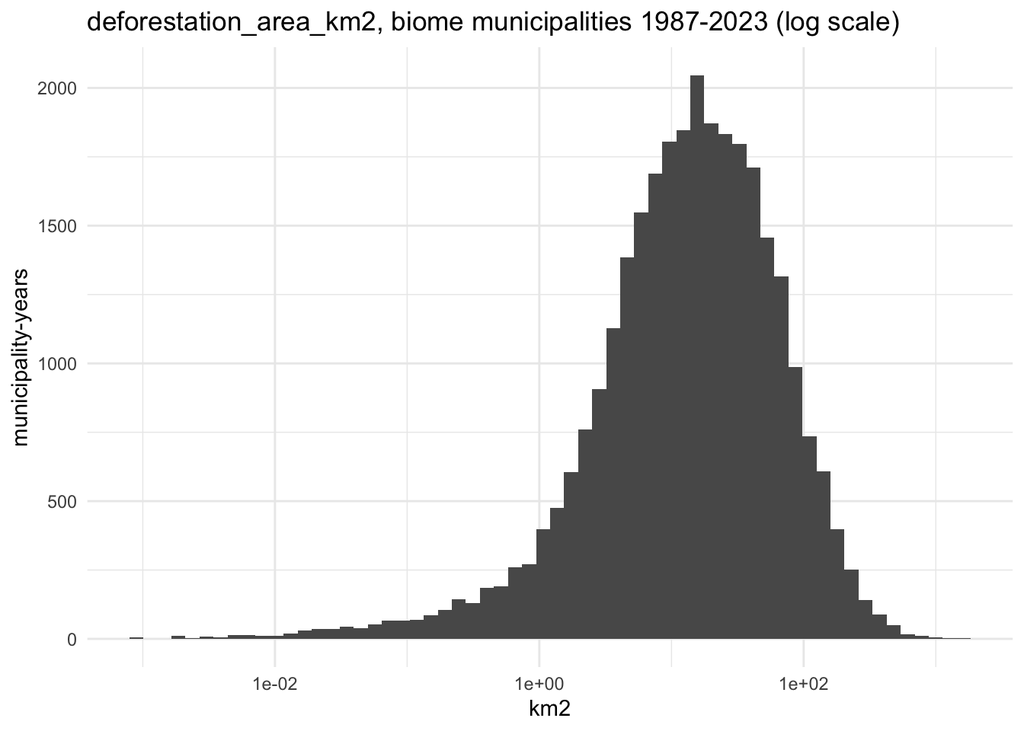

```r
ggplot(defor, aes(x = deforestation_area_km2)) +
  geom_histogram(bins = 60) +
  scale_x_log10() +
  labs(title = "deforestation_area_km2, biome municipalities 1987-2023 (log scale)",
       x = "km2", y = "municipality-years") +
  theme_minimal()
```

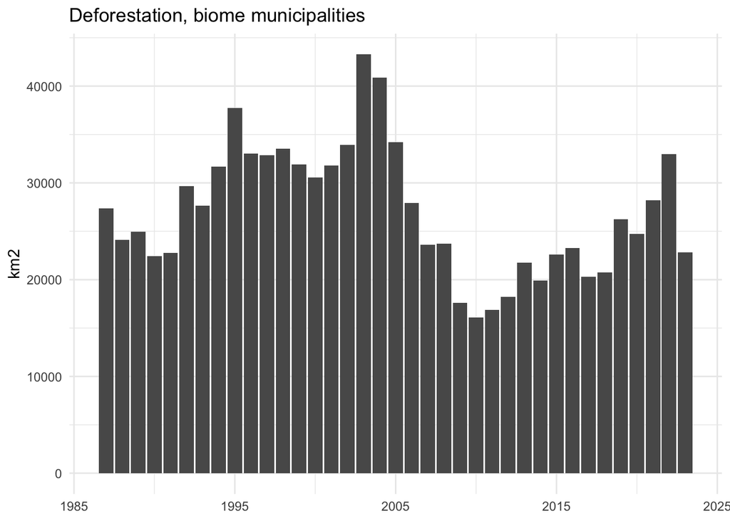

```r
defor %>%
  group_by(year) %>%
  summarise(total_km2 = sum(deforestation_area_km2)) %>%
  ggplot(aes(x = year, y = total_km2)) +
  geom_col() +
  labs(title = "Deforestation, biome municipalities", x = NULL, y = "km2") +
  theme_minimal()
```

## Q5. Do the aggregates match the MapBiomas platform for sampled municipalities?

What is checked: yearly deforestation for Acrelândia (AC) and Paragominas (PA), the two municipalities the original run compared by hand with the values shown on the MapBiomas platform.

```r
defor %>%
  filter(municipality %in% c("Acrelândia", "Paragominas")) %>%
  select(municipality, year, deforestation_area_km2, forest_area_km2) %>%
  pivot_wider(names_from = municipality, values_from = c(deforestation_area_km2, forest_area_km2)) %>%
  print(n = 40)
```

```
# A tibble: 37 × 5
    year deforestation_area_k…¹ deforestation_area_k…² forest_area_km2_Acre…³ forest_area_km2_Para…⁴
   <int>                  <dbl>                  <dbl>                  <dbl>                  <dbl>
 1  1987                   31.8                  102.                   1670.                 15647.
 2  1988                   27.0                   76.2                  1644.                 15587.
 3  1989                   19.6                  118.                   1625.                 15515.
 4  1990                   21.6                  431.                   1604.                 15389.
 5  1991                   18.1                   44.4                  1588.                 15562.
 6  1992                   29.5                  101.                   1561.                 15566.
 7  1993                   34.5                  122.                   1529.                 15527.
 8  1994                   41.7                  231.                   1488.                 15343.
 9  1995                   30.7                  211.                   1459.                 15266.
10  1996                   76.2                  159.                   1384.                 15235.
11  1997                   41.9                  385.                   1344.                 14971.
12  1998                   50.5                  285.                   1296.                 14821.
```

[output cut: 27 more lines]

**Finding.** The tables reproduce the series the original run (2025) compared against the platform and found consistent. The online comparison is a manual step and was not repeated in the rebuild; the tables are kept so that a reader can repeat it. **Decision.** none required. **Assertion.** none.

## Q6. Does Mojuí dos Campos carry data before its 2013 installation?

```r
defor %>%
  filter(geocode == "1504752") %>%
  summarise(years = n(), first_year = min(year), last_year = max(year),
            years_with_forest = sum(forest_area_km2 > 0))
```

```
# A tibble: 1 × 4
  years first_year last_year years_with_forest
  <int>      <int>     <int>             <int>
1    37       1987      2023                37
```

**Finding.** Yes: MapBiomas uses the current municipal mesh for the whole series, so Mojuí dos Campos (emancipated from Santarém in 2013) has values for all 37 years. The pipeline keeps it at this stage; it is dropped in the panel scripts because its social and economic series start in 2013. **Decision.** D-2026-10-05-l (downstream). **Assertion.** `N_MUNIC_BIOME_EXPECTED = 503` in `01-env-deforestation.R`.

## Q7. Which municipalities lack rows for some transition, and is the zero fill correct?

What is checked: the number of the four transitions present per biome municipality in the raw sheet, and the rows of any municipality with fewer than four.

```r
coverage <- nine %>%
  filter(transition_name %in% c(FOREST_TR, DEFOR_TR),
         as.character(geocode) %in% biome_amz$Geocódigo) %>%
  distinct(geocode, municipality, transition_name) %>%
  count(geocode, municipality, name = "transitions_present")
coverage %>% count(transitions_present)
```

```
# A tibble: 2 × 2
  transitions_present     n
                <int> <int>
1                   2     1
2                   4   502
```

```r
incomplete <- coverage %>% filter(transitions_present < 4)
incomplete
```

```
# A tibble: 1 × 3
  geocode municipality        transitions_present
    <dbl> <chr>                             <int>
1 1506401 Santa Cruz do Arari                   2
```

```r
nine %>%
  filter(geocode %in% incomplete$geocode, transition_name %in% c(FOREST_TR, DEFOR_TR)) %>%
  count(municipality, transition_name, class_level_1)
```

```
# A tibble: 4 × 4
  municipality        transition_name         class_level_1                       n
  <chr>               <chr>                   <chr>                           <int>
1 Santa Cruz do Arari Supressão Veg. Primária 2. Non Forest Natural Formation     2
2 Santa Cruz do Arari Veg. Primária           1. Forest                           3
3 Santa Cruz do Arari Veg. Primária           2. Non Forest Natural Formation     2
4 Santa Cruz do Arari Veg. Primária           5. Water and Marine Environment     1
```

**Finding.** One municipality, Santa Cruz do Arari (PA), has no secondary vegetation and no secondary suppression rows: its forest is primary vegetation alone and its deforestation primary suppression alone, which totals 16 hectares over the whole series. MapBiomas omits transitions with no pixels, so `values_fill = 0` in the wide reshape is the correct treatment. **Decision.** none required. **Assertion.** `01-env-deforestation.R`, output block (no NA in the area columns).

## Q8. Are geocode-year keys unique and the output columns complete?

```r
tibble(
  rows = nrow(defor),
  expected = 503 * length(1987:2023),
  geocodes = n_distinct(defor$geocode),
  duplicate_keys = sum(duplicated(paste(defor$geocode, defor$year))),
  na_forest_area = sum(is.na(defor$forest_area_km2)),
  na_deforestation_area = sum(is.na(defor$deforestation_area_km2)),
  na_rate = sum(is.na(defor$deforestation_forest_rate)),
  zero_forest_rows = sum(defor$forest_area_km2 == 0),
  na_z = sum(is.na(defor$deforestation_z))
)
```

```
# A tibble: 1 × 9
   rows expected geocodes duplicate_keys na_forest_area na_deforestation_area na_rate
  <int>    <dbl>    <int>          <int>          <int>                 <int>   <int>
1 29896    18611      808              0              0                     0       0
# ℹ 2 more variables: zero_forest_rows <int>, na_z <int>
```

## Q9. Does the denominator timing of the rate matter: the same year’s stock or the previous year’s? (phase 2, step 2.8, 2026-10-28)

What is checked: `deforestation_forest_rate` divides the year’s clearing by the same year’s forest stock (D-2026-10-06-d), the stock after the clearing, so it is clearing over what remains; the alternative divides by the previous year’s stock, the forest standing when the year began. Task 1.9 asks that the timing be recorded; before recording it, the two quotients are compared over the panel years, with the question whether the lagged stock is a closed balance (forest of t-1 = forest of t + clearing of t), which would make the lagged quotient a share bounded by one by construction.

```r
rates <- defor %>%
  arrange(geocode, year) %>%
  group_by(geocode) %>%
  mutate(forest_lag_km2 = lag(forest_area_km2),
         rate_contemp   = deforestation_forest_rate,
         rate_lagged    = deforestation_area_km2 / forest_lag_km2,
         stock_gap      = (forest_area_km2 + deforestation_area_km2) /
           forest_lag_km2 - 1) %>%
  ungroup() %>%
  filter(year %in% 2000:2020)
rates %>%
  summarise(cells = n(),
            max_contemp = max(rate_contemp), max_lagged = max(rate_lagged),
            p50_contemp = median(rate_contemp), p50_lagged = median(rate_lagged),
            over_one_contemp = sum(rate_contemp > 1),
            over_one_lagged = sum(rate_lagged > 1),
            pearson = cor(rate_contemp, rate_lagged),
            spearman = cor(rate_contemp, rate_lagged, method = "spearman"))
```

```
# A tibble: 1 × 9
  cells max_contemp max_lagged p50_contemp p50_lagged over_one_contemp over_one_lagged pearson
  <int>       <dbl>      <dbl>       <dbl>      <dbl>            <int>           <int>   <dbl>
1 16968       0.367      0.270      0.0141     0.0140                0               0   0.997
# ℹ 1 more variable: spearman <dbl>
```

```r
rel <- rates %>%
  mutate(rel = rate_contemp / rate_lagged - 1) %>%
  filter(is.finite(rel))
quantile(rel$rel, c(.01, .1, .5, .9, .99))
```

```
          1%          10%          50%          90%          99%
-0.037966668 -0.004064097  0.005752228  0.032838498  0.093904151
```

```r
rates %>%
  summarise(net_regrowth_cells = sum(forest_area_km2 > forest_lag_km2),
            stock_gap_over_5pct = sum(abs(stock_gap) > 0.05))
```

```
# A tibble: 1 × 2
  net_regrowth_cells stock_gap_over_5pct
               <int>               <int>
1               3615                 473
```

```r
rel %>%
  arrange(desc(abs(rel))) %>%
  transmute(municipality, state_abbreviation, year,
            forest_lag_km2 = round(forest_lag_km2),
            forest_area_km2 = round(forest_area_km2),
            deforestation_area_km2 = round(deforestation_area_km2, 1),
            rate_contemp = round(rate_contemp, 3),
            rate_lagged = round(rate_lagged, 3), rel = round(rel, 3)) %>%
  head(8)
```

```
# A tibble: 8 × 9
  municipality        state_abbreviation  year forest_lag_km2 forest_area_km2 deforestation_area_km2
  <chr>               <chr>              <int>          <dbl>           <dbl>                  <dbl>
1 Governador Nunes F… MA                  2000            432             317                  117.
2 Junco do Maranhão   MA                  2000            259             200                   61
3 Maranhãozinho       MA                  2007            126              98                   33.2
4 Eldorado do Carajás PA                  2004            597             473                  129.
5 Maracaçumé          MA                  2000            253             202                   51.6
6 Junco do Maranhão   MA                  2001            200             160                   43
7 Nova União          RO                  2019            157             127                   31.7
8 Junco do Maranhão   MA                  2007            109              89                   21.5
# ℹ 3 more variables: rate_contemp <dbl>, rate_lagged <dbl>, rel <dbl>
```

## Q10. Which municipalities does the nine-state sample add, and do the two flags partition it as expected? (phase 2, step 2.9, 2026-10-29)

What is checked: the biome filter of D-2026-10-06-c becomes two constant flags (task 1.1; D-2026-10-29-a). The interim output now carries every municipality of the nine Legal Amazon states; `biome_amazon` marks IBGE’s predominant biome Amazônia and `legal_amazon` marks IBGE’s list of the Legal Amazon municipalities on the 2022 mesh (`_data/raw/ibge/Municipios_da_Amazonia_Legal_2022.xlsx`, 772 rows). Checked here: the composition of the 808 by state, biome and flag; the agreement of municipality names between MapBiomas and the IBGE list; whether any added municipality has a zero forest stock or no clearing in the panel window; and how the added municipalities’ 2000 forest stocks and shares compare with the biome sample’s.

```r
flags <- defor %>%
  distinct(geocode, municipality, state_abbreviation, biome, biome_amazon, legal_amazon)
flags %>% count(biome, biome_amazon, legal_amazon)
```

```
# A tibble: 4 × 4
  biome    biome_amazon legal_amazon     n
  <chr>           <int>        <int> <int>
1 Amazônia            1            1   503
2 Cerrado             0            0    36
3 Cerrado             0            1   265
4 Pantanal            0            1     4
```

```r
flags %>%
  count(state_abbreviation, biome) %>%
  pivot_wider(names_from = biome, values_from = n, values_fill = 0)
```

```
# A tibble: 9 × 4
  state_abbreviation Amazônia Cerrado Pantanal
  <chr>                 <int>   <int>    <int>
1 AC                       22       0        0
2 AM                       62       0        0
3 AP                       16       0        0
4 MA                       93     124        0
5 MT                       76      61        4
6 PA                      144       0        0
7 RO                       52       0        0
8 RR                       15       0        0
9 TO                       23     116        0
```

```r
flags %>% filter(legal_amazon == 0L) %>% count(state_abbreviation, biome)
```

```
# A tibble: 1 × 3
  state_abbreviation biome       n
  <chr>              <chr>   <int>
1 MA                 Cerrado    36
```

```r
nine %>%
  distinct(geocode = as.character(geocode), municipality) %>%
  inner_join(biome, by = c("geocode" = "Geocódigo")) %>%
  filter(municipality != `Nome do município`) %>%
  select(geocode, mapbiomas = municipality, ibge = `Nome do município`, `Sigla da UF`)
```

```
# A tibble: 1 × 4
  geocode mapbiomas                 ibge                      `Sigla da UF`
  <chr>   <chr>                     <chr>                     <chr>
1 5107800 Santo Antônio de Leverger Santo Antônio do Leverger MT
```

```r
area <- read_rds("_data/interim/pam_ppm_munic_area_2022.rds")
window <- defor %>% filter(year %in% 2000:2020)
window %>%
  group_by(biome_amazon) %>%
  summarise(municipalities = n_distinct(geocode),
            zero_forest_cells = sum(forest_area_km2 == 0),
            zero_clearing_cells = sum(deforestation_area_km2 == 0),
            all_zero_clearing_munic = sum(tapply(deforestation_area_km2, geocode,
                                                 function(x) all(x == 0))),
            .groups = "drop")
```

```
# A tibble: 2 × 5
  biome_amazon municipalities zero_forest_cells zero_clearing_cells all_zero_clearing_munic
         <int>          <int>             <int>               <int>                   <int>
1            0            305                 0                   1                       0
2            1            503                 0                  38                       1
```

```r
q <- function(x) {
  tibble(p = c("p05", "p50", "p95"), value = round(quantile(x, c(.05, .5, .95)), 3))
}
window %>%
  filter(year == 2000) %>%
  left_join(area, by = "geocode") %>%
  mutate(forest_share = forest_area_km2 / munic_area_km2) %>%
  group_by(biome_amazon) %>%
  reframe(bind_rows(forest_km2 = q(forest_area_km2), forest_share = q(forest_share),
                    .id = "measure")) %>%
  pivot_wider(names_from = p, values_from = value)
```

```
# A tibble: 4 × 5
  biome_amazon measure          p05      p50       p95
         <int> <chr>          <dbl>    <dbl>     <dbl>
1            0 forest_km2   162.    1181.     8522.
2            0 forest_share   0.39     0.748     0.973
3            1 forest_km2   129.    1926.    31961.
4            1 forest_share   0.234    0.749     0.979
```

**Finding.** The nine states hold 808 municipalities: 503 with Amazônia as predominant biome (all nine states), 301 Cerrado (Maranhão 124, Tocantins 116, Mato Grosso 61) and 4 Pantanal (Mato Grosso). IBGE’s 2022 list has 772 Legal Amazon municipalities, every one in the nine states and every biome municipality among them; the 36 municipalities of the nine states outside it are Maranhão’s Cerrado east of the 44th meridian, so `biome_amazon` implies `legal_amazon` and the three groups are 503, 269 and 36. One name differs between MapBiomas and IBGE’s 2022 release: Santo Antônio de Leverger (MT), which IBGE now spells “do Leverger”; the panel keeps the MapBiomas spelling for every municipality. No municipality-year of 2000-2020 has a zero forest stock, so the clearing rate and the log exposure offset are defined everywhere; the one municipality without clearing over the window is Santa Cruz do Arari, inside the biome and known (Q7). The added municipalities are smaller but, on this aggregate, as vegetated as the biome’s: a median 2000 stock of 1,181 km² against 1,926 km², a 95th percentile of 8,522 km² against 31,961 km², and a median forest share of 0.75 of the municipal area in both groups (5th percentiles 0.39 and 0.23), because MapBiomas’s vegetation classes include the Cerrado’s natural formations. The “forest” of the added municipalities is therefore a different object, which the biome flag keeps separable in every analysis. **Decision.** D-2026-10-29-a (the nine-state sample, the two flags, the IBGE list as the Legal Amazon source, the MapBiomas spelling kept); supersedes D-2026-10-06-c. **Assertion.** `01-env-deforestation.R`, raw-state block (808 geocodes, 772 in the list and all inside the nine states, 503 biome municipalities all listed, 36 outside the list all Maranhão Cerrado, one name mismatch) and output block (808 × 37 rows; flags 0/1, constant within municipality, biome inside Legal Amazon, 503 and 772).